# 1. Introduction to Data Exploration

[figure not shown]

# 1. Introduction to Data Exploration

## 1.1. Philosophy

- Data **Exploration** is time consuming and often overlooked
- Often times, people tend to jump straight to modelling

Table of Contents:

1. Understand the **problem**
   - **Meaning and importance** of each variable
2. **Univariate** study
   - **Focusing** on the target `SalePrice`
   - Looking for variables **related** to `SalePrice`
3. **Multivariate** study
   - **Interactions** between `SalePrice` and chosen variables
   - Finding other **relevant** variables, **undirectly** related to `SalePrice`
4. Investigating initial **requirements**
   - What is the **overall picture** of the houses we are looking for?
5. Finding the **right house**
   - Finding the **best quality-price** relation within budget

# 1. Introduction to Data Exploration

## 1.2. Setting up

- We are going to use a **plotting** library called `seaborn`

To install it:

```python
!pip install seaborn
```

- `pandas` and `numpy`

```python
import pandas as pd
import numpy as np
```

- Plotting packages
  - `matplotlib`
  - `seaborn`

```python
import matplotlib.pyplot as plt
import seaborn as sns
```

- Loading data

```python
df = pd.read_csv('../data/housing_data.csv')
```

- Loading the feature description function

```python
def feature_description(search_feature):
    PATH = '../data/data_description.txt'
    with open(PATH, 'r') as fp:
        file_content = fp.read()
    feature_text = file_content.split('\n\n')
    for text in feature_text:
        first_word = text.split(' ')[0]
        if search_feature in first_word:
            print(text)
            return
feature_description("Alley")
```

```
Alley: Type of alley access to property
       Grvl	Gravel
       Pave	Paved
       NA 	No alley access
```

# 1. Introduction to Data Exploration

## 1.3. The Problem

We want to buy our dream-house in Boston! But the Internet is full of ads, and house offers, and we don't know where to start looking.

Moreover, house sellers are usually a little shady, and try to rip us off for a bigger comission.

Little do they know, that we are able of performing the fine arts of **Mathematics** and **Data Visualization**.

These tools will help us discerning how the **house features** are related to the house **price** - our ultimate goal.

We want to get the **best price** for our house, while on a tight budget.

We have some house qualities that we look for, when buying our dream-house:

- Garage
- Fireplace
- Living room with kitchen
- Garden space
- etc.

We'll have to understand:

- how the qualities we want relate to the price (how far can we go?)
- if a neighborhood is overpriced or not
- if a certain seller usually overprices the house
- if a desired quality is out of reach of our budget
- etc.

# 1. Introduction to Data Exploration

## 1.4. Philosophy on Data Exploration

- Jumping in directly to see what we have on the menu, we have a lot of variables
- We know that our target is `SalePrice` - the final price of the house
- How can we start researching, without knowing where to start?

```python
print(len(df.columns))
df.columns
```

```
81
```

```
Index(['Id', 'MSSubClass', 'MSZoning', 'LotFrontage', 'LotArea', 'Street',
       'Alley', 'LotShape', 'LandContour', 'Utilities', 'LotConfig',
       'LandSlope', 'Neighborhood', 'Condition1', 'Condition2', 'BldgType',
       'HouseStyle', 'OverallQual', 'OverallCond', 'YearBuilt', 'YearRemodAdd',
       'RoofStyle', 'RoofMatl', 'Exterior1st', 'Exterior2nd', 'MasVnrType',
       'MasVnrArea', 'ExterQual', 'ExterCond', 'Foundation', 'BsmtQual',
       'BsmtCond', 'BsmtExposure', 'BsmtFinType1', 'BsmtFinSF1',
       'BsmtFinType2', 'BsmtFinSF2', 'BsmtUnfSF', 'TotalBsmtSF', 'Heating',
       'HeatingQC', 'CentralAir', 'Electrical', '1stFlrSF', '2ndFlrSF',
       'LowQualFinSF', 'GrLivArea', 'BsmtFullBath', 'BsmtHalfBath', 'FullBath',
       'HalfBath', 'BedroomAbvGr', 'KitchenAbvGr', 'KitchenQual',
       'TotRmsAbvGrd', 'Functional', 'Fireplaces', 'FireplaceQu', 'GarageType',
       'GarageYrBlt', 'GarageFinish', 'GarageCars', 'GarageArea', 'GarageQual',
       'GarageCond', 'PavedDrive', 'WoodDeckSF', 'OpenPorchSF',
       'EnclosedPorch', '3SsnPorch', 'ScreenPorch', 'PoolArea', 'PoolQC',
       'Fence', 'MiscFeature', 'MiscVal', 'MoSold', 'YrSold', 'SaleType',
       'SaleCondition', 'SalePrice'],
      dtype='object')
```

- We will have to look at each one of 81 variables!
  - Understand their **meaning and importance**
- **Time-consuming** task, but we can focus our research
- We need to create a **uniform** method for our analysis
- This allows a **standardized** way to share our results with a **client**, and even our **future selves**
- **Document** conclusions, before they get lost!

# 1. Introduction to Data Exploration

## 1.5. Taking notes

- Here is a suggestion **method**. Each variable has the following information:
  1. Variable **Name**
  2. Variable **Type**
  3. Variable **segment** (semantic group)
  4. Variable **expectation**
  5. Conclusions
  6. Comments

### Variable Name

- Self explanatory

### Variable Type

- **NOT** Python **types**
- More general description
- Can be either
  - Numerical
  - Categorical - values are categories (i.e. Low, Medium, High)

```python
df['MSZoning'].head()
```

```
0    RL
1    RL
2    RL
3    RL
4    RL
Name: MSZoning, dtype: object
```

### Variable Segment

- We can divide variables into a semantic group
- A group that makes sense to us, as a Data Scientist
- According to this problem and data that we are given, we can define three segments:
  1. Building - physical qualities of the house (i.e. `OverallQual`)
  2. Space - space that the house takes (i.e. `TotalBsmtSF`)
  3. Location - where it is located (i.e. `Neighborhood`)

```python
df[['OverallQual', 'TotalBsmtSF', 'Neighborhood']].head()
```

|  | OverallQual | TotalBsmtSF | Neighborhood |
| --- | --- | --- | --- |
| 0 | 7 | 856 | CollgCr |
| 1 | 6 | 1262 | Veenker |
| 2 | 7 | 920 | CollgCr |
| 3 | 7 | 756 | Crawfor |
| 4 | 8 | 1145 | NoRidge |

### Variable Expectation

- Expected influence at **first glance**, on `SalePrice` (the objective(
- Options:
  1. Number scale (i.e. 1 to 10)
  2. Categorical scale (i.e. `Low`, `Medium`, `High`)
- Our *6th sense*
- Questions to ask:
  1. Do I think of this variable when buying a house?
  2. If so, how important would this variable be?
  3. Is this information contained in other variables?

### Conclusions

- **De facto importance** of the variable
- We can have the **same scale** as expectation
- Correction of our **expectation**

### Comments

- Any **additional observation** on this variable
  - **Interactions** with other variables
  - **Indirect** influence

# 2. Plotting and Data Overview

[figure not shown]

# 2. Plotting and Data Overview

## 2.1. Out first plot - Scatter

- Collection of points placed on Cartesian Coordinates
- Displays values from two variables

### Looks

[figure not shown]

### When to use

- **Paired** numerical data
- Check if one variable **impacts** the other
- Can detect **relationships or correlations** between the two variables
- Checking the relationship between `GrLivArea` and `SalePrice`

```python
feature_description('GrLivArea')
```

```
GrLivArea: Above grade (ground) living area square feet
```

```python
var = 'GrLivArea'
data = df[['SalePrice', var]]
data.head()
```

|  | SalePrice | GrLivArea |
| --- | --- | --- |
| 0 | 208500 | 1710 |
| 1 | 181500 | 1262 |
| 2 | 223500 | 1786 |
| 3 | 140000 | 1717 |
| 4 | 250000 | 2198 |

- The `seaborn` package has a function called `scatterplot`
- You can do a `Scatter Plot` by doing `sns.scatterplot(data, x, y)`
- The **function** takes three arguments:
  - The data - our `pd.DataFrame`
  - `x` - what variable should we put on the **x** axis
  - `y` - what variable should we put on the **x** axis

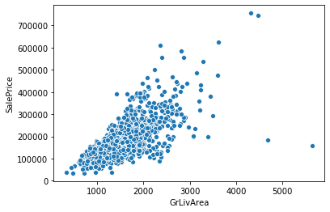

```python
sns.scatterplot(data=data, x=var, y='SalePrice')
```

Taking notes:

- **Name**: `GrLivArea`
- **Type**: `Numeric`
- **Segment**: `Space`
- **Expectation**: `High`
- **Conclusions**:
- **Comments**:
  - `SalePrice` seems to increase with `GrLivArea`
  - Some weird points (outliers), out of the cloud
  - Spreads as both values increase
- Put the code in a function, so we can use it later

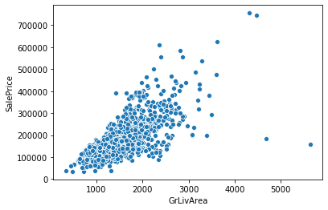

```python
def scatter(df, var):
    data = df[['SalePrice', var]]
    return sns.scatterplot(data=data, x=var, y='SalePrice')
scatter(df, 'GrLivArea')
```

# 2. Plotting and Data Overview

## 2.2. Exercise - Exploring Relations to `SalePrice`

- Let's have a first look at our **numeric** variables.
- Look for relations and correlations between the variable and `SalePrice`
- Take notes on the variable
- **`[OBJECTIVE]`**: Finding 5 variables that are **expected** to have a `HIGH` influence
- Selecting variables with `Numeric` dtype
- **`[GOOGLE]`**: Search for `pandas select numeric columns`

```python
numerics = ['int16', 'int32', 'int64', 'float16', 'float32', 'float64']

sub_df = df.select_dtypes(include=numerics)
sub_df = sub_df.drop(['Id'], axis=1)
print(len(sub_df.columns))
sub_df.columns
```

```
37
```

```
Index(['MSSubClass', 'LotFrontage', 'LotArea', 'OverallQual', 'OverallCond',
       'YearBuilt', 'YearRemodAdd', 'MasVnrArea', 'BsmtFinSF1', 'BsmtFinSF2',
       'BsmtUnfSF', 'TotalBsmtSF', '1stFlrSF', '2ndFlrSF', 'LowQualFinSF',
       'GrLivArea', 'BsmtFullBath', 'BsmtHalfBath', 'FullBath', 'HalfBath',
       'BedroomAbvGr', 'KitchenAbvGr', 'TotRmsAbvGrd', 'Fireplaces',
       'GarageYrBlt', 'GarageCars', 'GarageArea', 'WoodDeckSF', 'OpenPorchSF',
       'EnclosedPorch', '3SsnPorch', 'ScreenPorch', 'PoolArea', 'MiscVal',
       'MoSold', 'YrSold', 'SalePrice'],
      dtype='object')
```

- Dividng in groups of 3

```python
col_groups = []
for i in range(0, 37-3, 3):
    cols = sub_df.columns[i:i+3]
    col_groups.append(cols)
col_groups
```

```
[Index(['MSSubClass', 'LotFrontage', 'LotArea'], dtype='object'),
 Index(['OverallQual', 'OverallCond', 'YearBuilt'], dtype='object'),
 Index(['YearRemodAdd', 'MasVnrArea', 'BsmtFinSF1'], dtype='object'),
 Index(['BsmtFinSF2', 'BsmtUnfSF', 'TotalBsmtSF'], dtype='object'),
 Index(['1stFlrSF', '2ndFlrSF', 'LowQualFinSF'], dtype='object'),
 Index(['GrLivArea', 'BsmtFullBath', 'BsmtHalfBath'], dtype='object'),
 Index(['FullBath', 'HalfBath', 'BedroomAbvGr'], dtype='object'),
 Index(['KitchenAbvGr', 'TotRmsAbvGrd', 'Fireplaces'], dtype='object'),
 Index(['GarageYrBlt', 'GarageCars', 'GarageArea'], dtype='object'),
 Index(['WoodDeckSF', 'OpenPorchSF', 'EnclosedPorch'], dtype='object'),
 Index(['3SsnPorch', 'ScreenPorch', 'PoolArea'], dtype='object'),
 Index(['MiscVal', 'MoSold', 'YrSold'], dtype='object')]
```

- Plotting groups of 3 variables

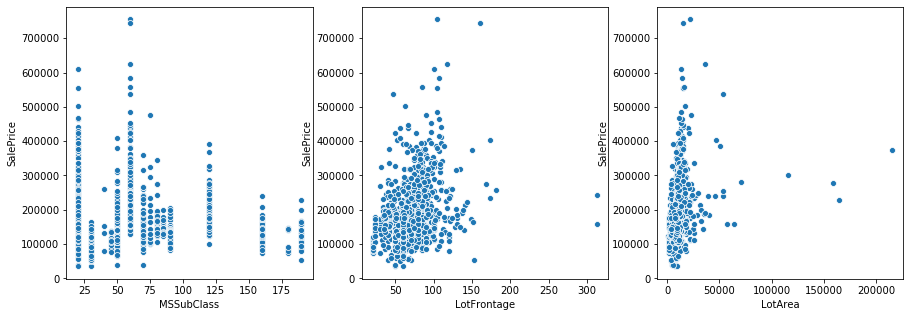

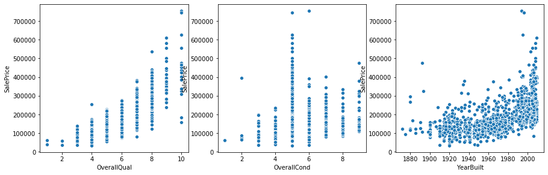

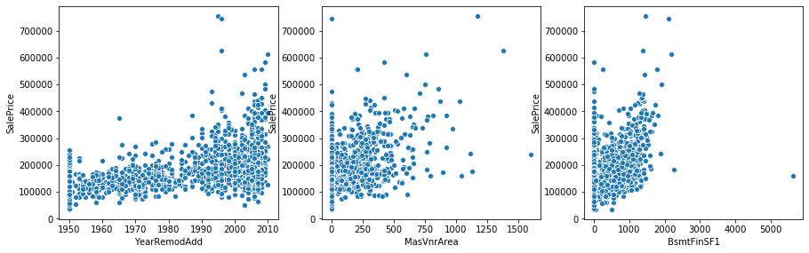

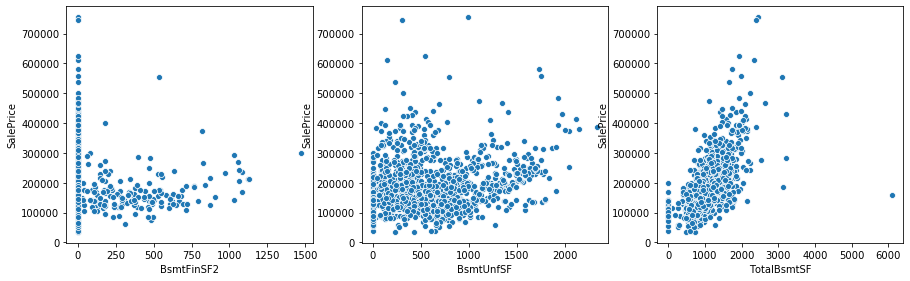

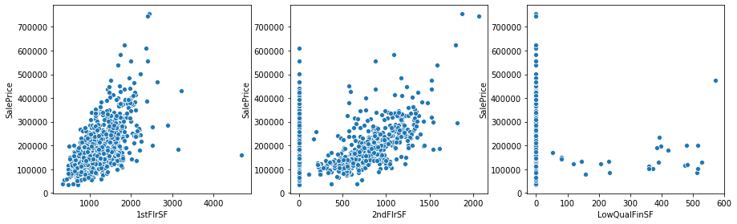

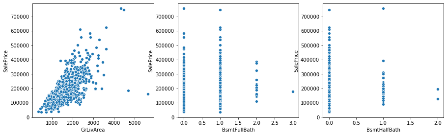

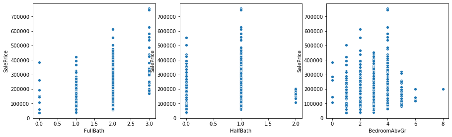

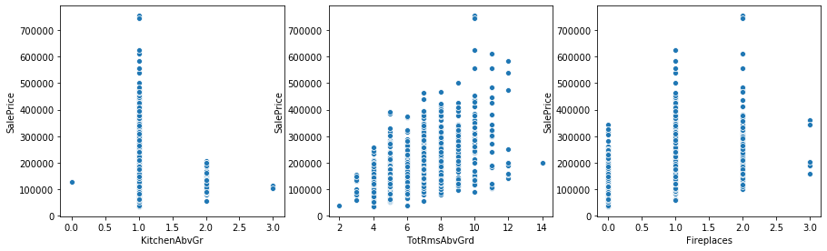

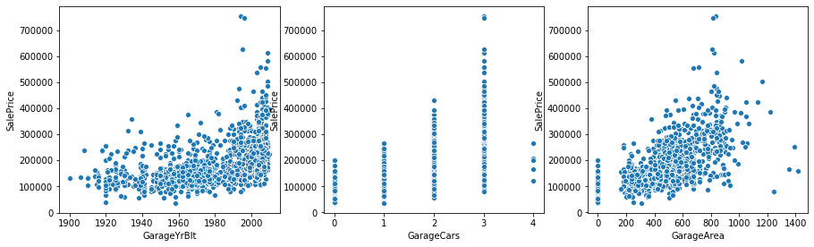

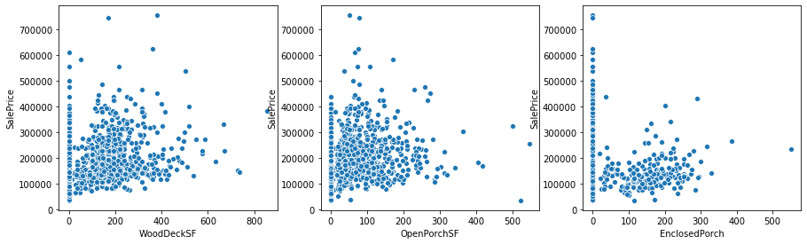

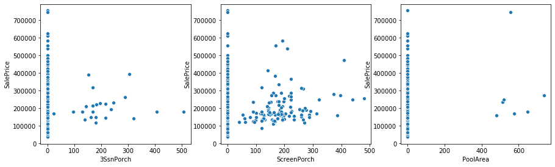

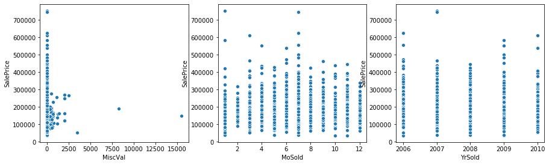

```python
for i, cols in enumerate(col_groups):
    plt.subplots(figsize=(15, 5*(i+1)))
    for j, c in enumerate(cols):
        plt.subplot(i+1, 3, j+1)
        f = scatter(df, c)
    plt.show()
```

# 2. Plotting and Data Overview

## 2.3. Conclusions

I went through this process and concluded that the following variables can play an important role in this problem (`HIGH` expectation):

- `Building` variables:
  - `OverallQual`
  - `YearBuilt`
- `Space` variables:
  - `TotalBsmtSF`
  - `GrLivArea`
  - `1stFlrSf`
- We only analyzed `Numerical` variables though
- We need another strategy for `Categorical` variables
- The main point was to build expectations on our `Numerical` variables

# 3. Investigating Categorical Data

[figure not shown]

# 3. Investigating Categorical Data

## 3.1 New Plot - `BoxPlot`

- Convenient way of visually displaying the data distribution through their quartiles.
- **`[QUARTILE]`**: a type of **quantile** which divides the number of data points into four more or less equal parts, or **quarters**.

[figure not shown]

### How to interpret

- Lines extending parallel from the boxes are known as the “whiskers”
  - indicate variability outside the upper and lower quartiles
- Outliers are plotted as individual dots that are in-line with whiskers

### When to use

- Know what the key values are, such as:
  - median
- Check outliers and what their values are.
- Is the data symmetrical?
- How tightly is the data grouped.
- If the data is skewed and if so, in what direction.

# 3. Investigating Categorical Data

## 3.2. An example

- If we look at `OverallQual` description, we can see that the variable is in reality `Categorical`

```python
feature_description('OverallQual')
```

```
OverallQual: Rates the overall material and finish of the house
       10	Very Excellent
       9	Excellent
       8	Very Good
       7	Good
       6	Above Average
       5	Average
       4	Below Average
       3	Fair
       2	Poor
       1	Very Poor
```

```python
df['OverallQual'].head()
```

```
0    7
1    6
2    7
3    7
4    8
Name: OverallQual, dtype: int64
```

```python
df['OverallQual'].value_counts()
```

```
5     397
6     374
7     319
8     168
4     116
9      43
3      20
10     18
2       3
1       2
Name: OverallQual, dtype: int64
```

- The `seaborn` package comes with a `sns.boxplot` **function**
- Similarly to `sns.scatterplot`, we have to provide **data**, **x** and **y** variables

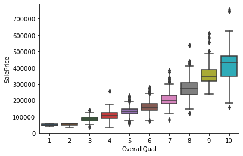

```python
var = 'OverallQual'
data = df[['SalePrice', var]]
sns.boxplot(data=data, x=var, y="SalePrice")
```

- Putting it in a function for later use

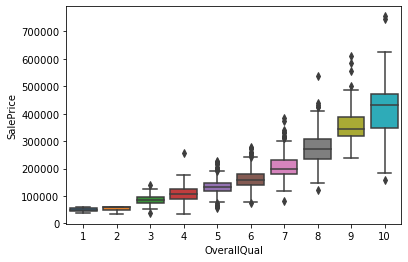

```python
def boxplot(df, var):
    data = df[['SalePrice', var]]
    fig = sns.boxplot(x=var, y="SalePrice", data=data)
    return fig
boxplot(df, 'OverallQual')
```

# 3. Investigating Categorical Data

## 3.3. Investigating `Categorical` variables

- As we did for `Numericals` we will do for `Categoricals`
- This time around with `BoxPlot`
- Select `Categorical` dtypes (`object`)

```python
categorical = ['object']

sub2_df = df.select_dtypes(include=categorical)
print(len(sub2_df.columns))
sub2_df.columns
```

```
43
```

```
Index(['MSZoning', 'Street', 'Alley', 'LotShape', 'LandContour', 'Utilities',
       'LotConfig', 'LandSlope', 'Neighborhood', 'Condition1', 'Condition2',
       'BldgType', 'HouseStyle', 'RoofStyle', 'RoofMatl', 'Exterior1st',
       'Exterior2nd', 'MasVnrType', 'ExterQual', 'ExterCond', 'Foundation',
       'BsmtQual', 'BsmtCond', 'BsmtExposure', 'BsmtFinType1', 'BsmtFinType2',
       'Heating', 'HeatingQC', 'CentralAir', 'Electrical', 'KitchenQual',
       'Functional', 'FireplaceQu', 'GarageType', 'GarageFinish', 'GarageQual',
       'GarageCond', 'PavedDrive', 'PoolQC', 'Fence', 'MiscFeature',
       'SaleType', 'SaleCondition'],
      dtype='object')
```

- Divide in groups of 3

```python
col_groups2 = []
for i in range(0, 43, 3):
    cols = sub2_df.columns[i:i+3]
    col_groups2.append(cols)
col_groups2
```

```
[Index(['MSZoning', 'Street', 'Alley'], dtype='object'),
 Index(['LotShape', 'LandContour', 'Utilities'], dtype='object'),
 Index(['LotConfig', 'LandSlope', 'Neighborhood'], dtype='object'),
 Index(['Condition1', 'Condition2', 'BldgType'], dtype='object'),
 Index(['HouseStyle', 'RoofStyle', 'RoofMatl'], dtype='object'),
 Index(['Exterior1st', 'Exterior2nd', 'MasVnrType'], dtype='object'),
 Index(['ExterQual', 'ExterCond', 'Foundation'], dtype='object'),
 Index(['BsmtQual', 'BsmtCond', 'BsmtExposure'], dtype='object'),
 Index(['BsmtFinType1', 'BsmtFinType2', 'Heating'], dtype='object'),
 Index(['HeatingQC', 'CentralAir', 'Electrical'], dtype='object'),
 Index(['KitchenQual', 'Functional', 'FireplaceQu'], dtype='object'),
 Index(['GarageType', 'GarageFinish', 'GarageQual'], dtype='object'),
 Index(['GarageCond', 'PavedDrive', 'PoolQC'], dtype='object'),
 Index(['Fence', 'MiscFeature', 'SaleType'], dtype='object'),
 Index(['SaleCondition'], dtype='object')]
```

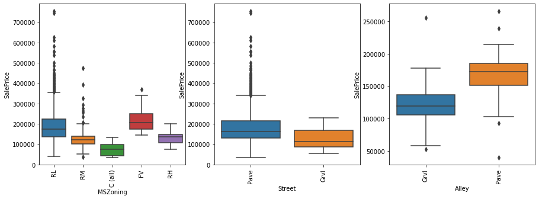

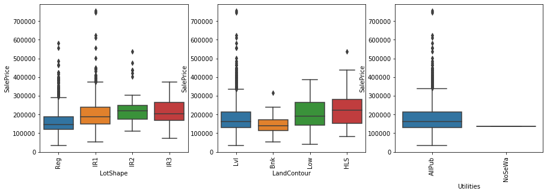

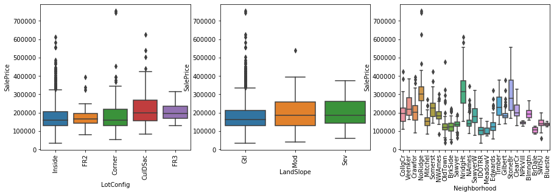

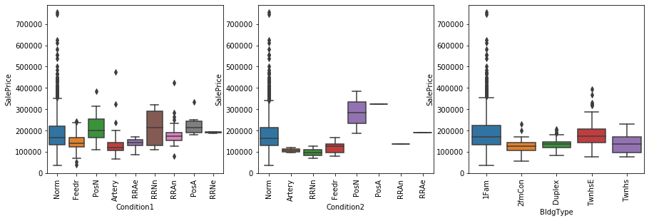

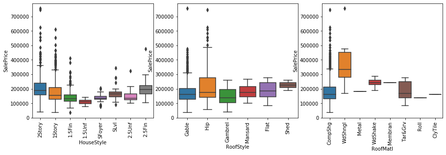

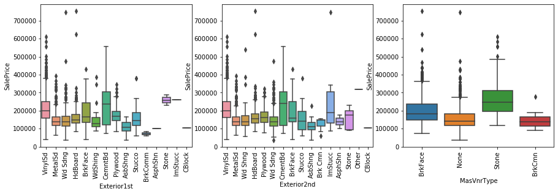

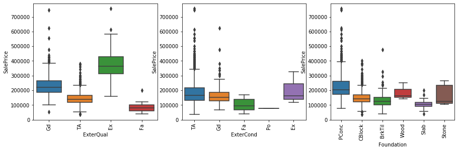

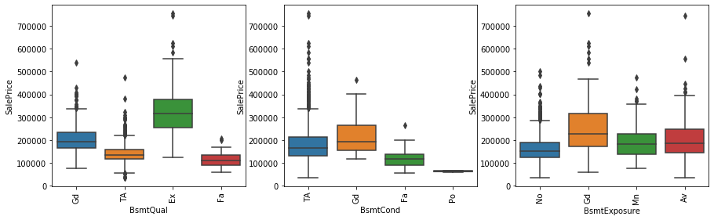

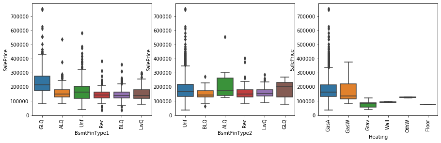

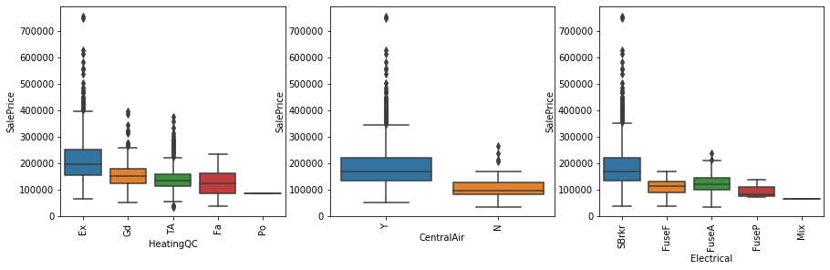

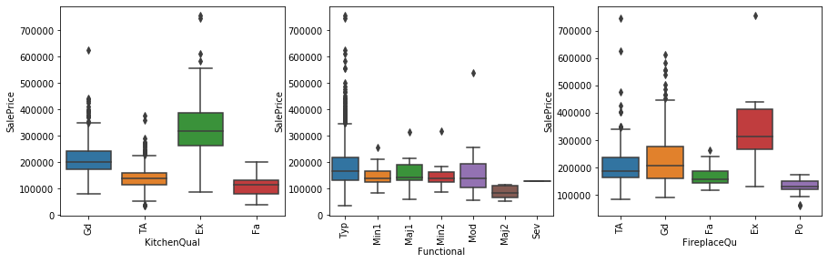

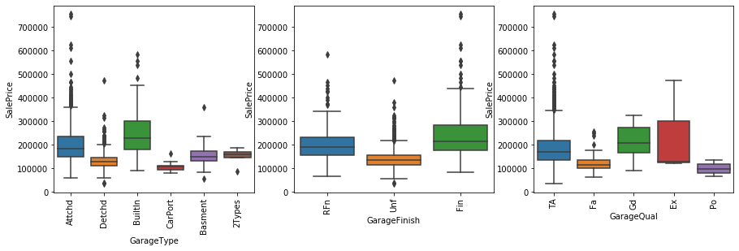

[3 more figures not shown]

```python
for i, cols in enumerate(col_groups2):
    plt.subplots(figsize=(15, 5*(i+1)))
    for j, c in enumerate(cols):
        plt.subplot(i+1, 3, j+1)
        plt.xticks(rotation=90)
        f = boxplot(df, c)
    plt.show()
```

# 3. Investigating Categorical Data

## 3.4. Conclusions

- Even though we can see some categories which tend to have an higher price:
  - Variable as a whole is not expressive (low to medium expectation)
  - Lots of outliers
- I'd rather trust the **linear** relationships of previous variables

# 4. Investigating the target `SalePrice`

[figure not shown]

# 4. Investigating the target `SalePrice`

## 4.1. The overall picture

- `SalePrice` is the **target** of our research
- **`[OBJECTIVE]`**: Getting the better price for our dream-home
- We want to find out
  - the **relationships** of our target to other variables (*close friends*)
  - shape and behavior of `SalePrice`
  - what influences the `SalePrice` the most
- Overall **statistics** are a great way to start

# 4. Investigating the target `SalePrice`

## 4.2. Pandas Statistics

- Just like `numpy`, `pandas` is also capable of calculating statistics
- The way of calculating the statistics is the same
- We **select** a **column** and use `pd.DataFrame.mean()` to get the **mean**

```python
df['SalePrice'].mean()
```

```
180921.19589041095
```

- We can use `pd.DataFrame.describe()` to have an overall picture of the whole dataset

```python
df.describe()
```

|  | Id | MSSubClass | LotFrontage | LotArea | OverallQual | OverallCond | YearBuilt | YearRemodAdd | MasVnrArea | BsmtFinSF1 | ... | WoodDeckSF | OpenPorchSF | EnclosedPorch | 3SsnPorch | ScreenPorch | PoolArea | MiscVal | MoSold | YrSold | SalePrice |
| --- | --- | --- | --- | --- | --- | --- | --- | --- | --- | --- | --- | --- | --- | --- | --- | --- | --- | --- | --- | --- | --- |
| count | 1460.000000 | 1460.000000 | 1201.000000 | 1460.000000 | 1460.000000 | 1460.000000 | 1460.000000 | 1460.000000 | 1452.000000 | 1460.000000 | ... | 1460.000000 | 1460.000000 | 1460.000000 | 1460.000000 | 1460.000000 | 1460.000000 | 1460.000000 | 1460.000000 | 1460.000000 | 1460.000000 |
| mean | 730.500000 | 56.897260 | 70.049958 | 10516.828082 | 6.099315 | 5.575342 | 1971.267808 | 1984.865753 | 103.685262 | 443.639726 | ... | 94.244521 | 46.660274 | 21.954110 | 3.409589 | 15.060959 | 2.758904 | 43.489041 | 6.321918 | 2007.815753 | 180921.195890 |
| std | 421.610009 | 42.300571 | 24.284752 | 9981.264932 | 1.382997 | 1.112799 | 30.202904 | 20.645407 | 181.066207 | 456.098091 | ... | 125.338794 | 66.256028 | 61.119149 | 29.317331 | 55.757415 | 40.177307 | 496.123024 | 2.703626 | 1.328095 | 79442.502883 |
| min | 1.000000 | 20.000000 | 21.000000 | 1300.000000 | 1.000000 | 1.000000 | 1872.000000 | 1950.000000 | 0.000000 | 0.000000 | ... | 0.000000 | 0.000000 | 0.000000 | 0.000000 | 0.000000 | 0.000000 | 0.000000 | 1.000000 | 2006.000000 | 34900.000000 |
| 25% | 365.750000 | 20.000000 | 59.000000 | 7553.500000 | 5.000000 | 5.000000 | 1954.000000 | 1967.000000 | 0.000000 | 0.000000 | ... | 0.000000 | 0.000000 | 0.000000 | 0.000000 | 0.000000 | 0.000000 | 0.000000 | 5.000000 | 2007.000000 | 129975.000000 |
| 50% | 730.500000 | 50.000000 | 69.000000 | 9478.500000 | 6.000000 | 5.000000 | 1973.000000 | 1994.000000 | 0.000000 | 383.500000 | ... | 0.000000 | 25.000000 | 0.000000 | 0.000000 | 0.000000 | 0.000000 | 0.000000 | 6.000000 | 2008.000000 | 163000.000000 |
| 75% | 1095.250000 | 70.000000 | 80.000000 | 11601.500000 | 7.000000 | 6.000000 | 2000.000000 | 2004.000000 | 166.000000 | 712.250000 | ... | 168.000000 | 68.000000 | 0.000000 | 0.000000 | 0.000000 | 0.000000 | 0.000000 | 8.000000 | 2009.000000 | 214000.000000 |
| max | 1460.000000 | 190.000000 | 313.000000 | 215245.000000 | 10.000000 | 9.000000 | 2010.000000 | 2010.000000 | 1600.000000 | 5644.000000 | ... | 857.000000 | 547.000000 | 552.000000 | 508.000000 | 480.000000 | 738.000000 | 15500.000000 | 12.000000 | 2010.000000 | 755000.000000 |

8 rows × 38 columns

- We can also do it for just **one column**

```python
df['SalePrice'].describe()
```

```
count      1460.000000
mean     180921.195890
std       79442.502883
min       34900.000000
25%      129975.000000
50%      163000.000000
75%      214000.000000
max      755000.000000
Name: SalePrice, dtype: float64
```

- Minimum price is greater than 0
  - Good, means data is clean
- Mean is closer to the minimum than to the maximum

# 4. Investigating the target `SalePrice`

## 4.3. Distribution

- We can look at the distribution of a variable to get a visual sense of it's spread
- How are values **populated** around the mean?
- Does the distibution have long tails?

[figure not shown]

- Calculating **distributions** is a **very HARD** problem
- But we have alternatives

# 4. Investigating the target `SalePrice`

## 4.4. New plot - `Histogram`

### Looks

[figure not shown]

### How to interpret

- Visualises the **distribution** of data over a **continuous** or **discrete** interval
- Each bar in a `Histogram` represents the frequency at each interval/bin
- For instance:
  - First bin: `[0, 10[`
  - Second bin: `[10, 20[`

### When to use

- Give an estimate as to where values are **concentrated**
- **Extremes** and **gaps** or **unusual** values
- They are also useful for giving a **rough view** of the probability distribution.

# 4. Investigating the target `SalePrice`

## 4.5. `Histogram` example

- We can use Seaborn's `sns.distplot` to look at the `Histogram`
- We can define the number of **bins** we want to divide our data in

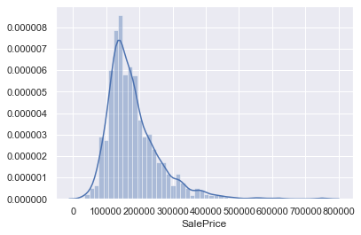

```python
sns.distplot(df['SalePrice'], bins=50)
```

**Conclusions**:

- **Deviates** from the normal distribution
- Has positive **skewness**
- **Peakedness** around the mean

# 4. Investigating the target `SalePrice`

## 4.5. Relations to picked variables

- In a jungle of data we **must pick our battles**!
- We should always start with the **main culprits**, and afterwards look for **other suspects**
- For now main culprits are:
  - `GrLivArea`
  - `TotalBsmtSF`
  - `OverallQual`
  - `Yearbuilt`
  - `1stFlrSF`
- Let's focus attention on these variables